# A6 - Titantic

## 0. Intro

```python
import numpy as np
import matplotlib.pyplot as plt
import pandas as pd
import seaborn as sns
import warnings
warnings.filterwarnings("ignore")

from sklearn import model_selection
from sklearn.model_selection import train_test_split
from sklearn import linear_model
from sklearn.linear_model import LogisticRegression
from sklearn.ensemble import RandomForestClassifier
from sklearn.tree import DecisionTreeClassifier
from sklearn.neighbors import KNeighborsClassifier
from sklearn import metrics
from sklearn.model_selection import GridSearchCV
```

```python
df = pd.read_csv('titanic.csv')
```

```python
df
```

|  | PassengerId | Pclass | Name | Sex | Age | SibSp | Parch | Ticket | Fare | Cabin | Embarked | Survived |
| --- | --- | --- | --- | --- | --- | --- | --- | --- | --- | --- | --- | --- |
| 0 | 1 | 3 | Braund, Mr. Owen Harris | male | 22.0 | 1 | 0 | A/5 21171 | 7.2500 | NaN | S | 0 |
| 1 | 2 | 1 | Cumings, Mrs. John Bradley (Florence Briggs Th... | female | 38.0 | 1 | 0 | PC 17599 | 71.2833 | C85 | C | 1 |
| 2 | 3 | 3 | Heikkinen, Miss. Laina | female | 26.0 | 0 | 0 | STON/O2. 3101282 | 7.9250 | NaN | S | 1 |
| 3 | 4 | 1 | Futrelle, Mrs. Jacques Heath (Lily May Peel) | female | 35.0 | 1 | 0 | 113803 | 53.1000 | C123 | S | 1 |
| 4 | 5 | 3 | Allen, Mr. William Henry | male | 35.0 | 0 | 0 | 373450 | 8.0500 | NaN | S | 0 |
| ... | ... | ... | ... | ... | ... | ... | ... | ... | ... | ... | ... | ... |
| 886 | 887 | 2 | Montvila, Rev. Juozas | male | 27.0 | 0 | 0 | 211536 | 13.0000 | NaN | S | 0 |
| 887 | 888 | 1 | Graham, Miss. Margaret Edith | female | 19.0 | 0 | 0 | 112053 | 30.0000 | B42 | S | 1 |
| 888 | 889 | 3 | Johnston, Miss. Catherine Helen "Carrie" | female | NaN | 1 | 2 | W./C. 6607 | 23.4500 | NaN | S | 0 |
| 889 | 890 | 1 | Behr, Mr. Karl Howell | male | 26.0 | 0 | 0 | 111369 | 30.0000 | C148 | C | 1 |
| 890 | 891 | 3 | Dooley, Mr. Patrick | male | 32.0 | 0 | 0 | 370376 | 7.7500 | NaN | Q | 0 |

891 rows × 12 columns

Pclass: Ticket class (1 = 1st, 2 = 2nd, 3 = 3rd)  
SibSp: # of siblings / spouses aboard the Titanic  
Parch: # of parents / children aboard  
Embarked: Port of Embarkation (C = Cherbourg, Q = Queenstown, S = Southampton)  
Survival: 0 = No, 1 = Yes

### Understand the problem:

We are given the information of passengers on the Titanic. (name, sex, age, cabin, ticket, etc)  
We want to clean and analyze the given data, and use the features to create models and predict whether a passenger on the Titanic would have been survived or not.

## 1. Check data completeness

```python
df.info()
```

```
<class 'pandas.core.frame.DataFrame'>
RangeIndex: 891 entries, 0 to 890
Data columns (total 12 columns):
 #   Column       Non-Null Count  Dtype
---  ------       --------------  -----
 0   PassengerId  891 non-null    int64
 1   Pclass       891 non-null    int64
 2   Name         891 non-null    object
 3   Sex          891 non-null    object
 4   Age          714 non-null    float64
 5   SibSp        891 non-null    int64
 6   Parch        891 non-null    int64
 7   Ticket       891 non-null    object
 8   Fare         891 non-null    float64
 9   Cabin        204 non-null    object
 10  Embarked     889 non-null    object
 11  Survived     891 non-null    int64
dtypes: float64(2), int64(5), object(5)
memory usage: 83.7+ KB
```

**The dataset has 891 data with 11 features and the target "survived" column.**

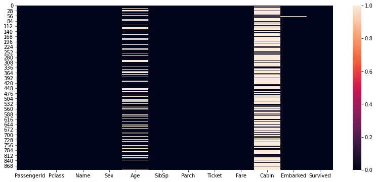

```python
plt.figure(figsize=(14,6))
sns.heatmap(df.isnull())
```

**As we can see, most of the columns contains no null value, meaning that the completeness of this dataset is good. There are some null values in the age column. Also, in the Cabin column, most of the values are null. And there are few values in Embarked column are null.**

```python
# Calculate the percent of null value in each column
count = df.isnull().sum()
percent = round(df.isnull().sum() / df.isnull().count()*100, 2)
nulls = pd.concat([count, percent], axis=1, keys=['count', 'percentage'])
nulls
```

|  | count | percentage |
| --- | --- | --- |
| PassengerId | 0 | 0.00 |
| Pclass | 0 | 0.00 |
| Name | 0 | 0.00 |
| Sex | 0 | 0.00 |
| Age | 177 | 19.87 |
| SibSp | 0 | 0.00 |
| Parch | 0 | 0.00 |
| Ticket | 0 | 0.00 |
| Fare | 0 | 0.00 |
| Cabin | 687 | 77.10 |
| Embarked | 2 | 0.22 |
| Survived | 0 | 0.00 |

## 2. EDA

```
3    491
1    216
2    184
Name: Pclass, dtype: int64
```

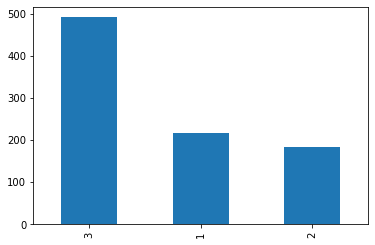

```python
# Check the distribution of the 'Pclass' column
print(df['Pclass'].value_counts())
df['Pclass'].value_counts().plot(kind='bar')
```

```
male      577
female    314
Name: Sex, dtype: int64
```

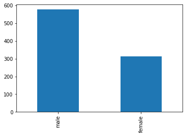

```python
# Check the distribution of the 'Sex' column
print(df['Sex'].value_counts())
df['Sex'].value_counts().plot(kind='bar')
```

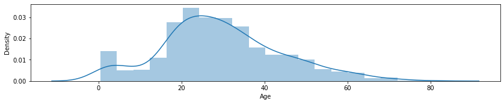

```python
# Check the distribution of the 'Age' column
plt.figure(figsize=(14,8))
plt.subplot(3, 1, 1); sns.distplot(df['Age'])
plt.xlabel('Age')
```

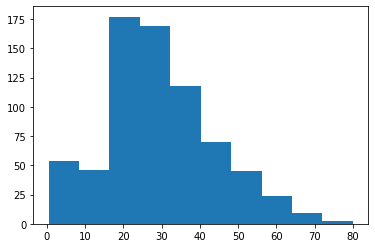

```python
plt.hist(df['Age'])
```

```
0    608
1    209
2     28
4     18
3     16
8      7
5      5
Name: SibSp, dtype: int64
```

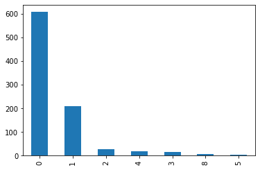

```python
# Check the distribution of the 'SibSp' column
print(df['SibSp'].value_counts())
df['SibSp'].value_counts().plot(kind='bar')
```

```
0    678
1    118
2     80
5      5
3      5
4      4
6      1
Name: Parch, dtype: int64
```

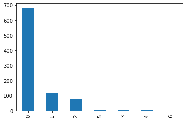

```python
# Check the distribution of the 'Parch' column
print(df['Parch'].value_counts())
df['Parch'].value_counts().plot(kind='bar')
```

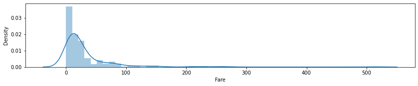

```python
# Check the distribution of the 'Fare' column
plt.figure(figsize=(14,8))
plt.subplot(3, 1, 1); sns.distplot(df['Fare'])
plt.xlabel('Fare')
```

```python
df['Fare'].mode()
```

```
0    8.05
dtype: float64
```

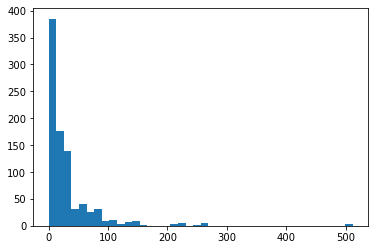

```python
plt.hist(df['Fare'], bins=40)
plt.show()
```

```
S    644
C    168
Q     77
Name: Embarked, dtype: int64
```

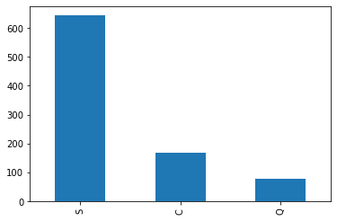

```python
# Check the distribution of the 'Embarked' column
print(df['Embarked'].value_counts())
df['Embarked'].value_counts().plot(kind='bar')
```

```
0    549
1    342
Name: Survived, dtype: int64
```

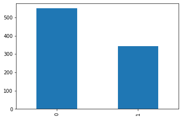

```python
# Check the distribution of the 'Survived' column
print(df['Survived'].value_counts())
df['Survived'].value_counts().plot(kind='bar')
```

## 3. Data Cleaning & Deal With Missing Value

### 3.1 Drop unrelated columns

```python
# The passenger id, name, ticket would contribute little to the prediction.
# Drop them from the table
df = df.drop(columns = ['PassengerId', 'Ticket', 'Name'])
```

### 3.2 Fill in Null value in 'Age'

```python
# Fill in the null value in 'Age' column with mean value of 'Age' column
df['Age'].describe()
```

```
count    714.000000
mean      29.699118
std       14.526497
min        0.420000
25%       20.125000
50%       28.000000
75%       38.000000
max       80.000000
Name: Age, dtype: float64
```

```python
ages = df['Age'].copy()
ages[np.isnan(df['Age'])] = int(df['Age'].mean())
df['Age'] = ages
df
```

|  | Pclass | Sex | Age | SibSp | Parch | Fare | Cabin | Embarked | Survived |
| --- | --- | --- | --- | --- | --- | --- | --- | --- | --- |
| 0 | 3 | male | 22.0 | 1 | 0 | 7.2500 | NaN | S | 0 |
| 1 | 1 | female | 38.0 | 1 | 0 | 71.2833 | C85 | C | 1 |
| 2 | 3 | female | 26.0 | 0 | 0 | 7.9250 | NaN | S | 1 |
| 3 | 1 | female | 35.0 | 1 | 0 | 53.1000 | C123 | S | 1 |
| 4 | 3 | male | 35.0 | 0 | 0 | 8.0500 | NaN | S | 0 |
| ... | ... | ... | ... | ... | ... | ... | ... | ... | ... |
| 886 | 2 | male | 27.0 | 0 | 0 | 13.0000 | NaN | S | 0 |
| 887 | 1 | female | 19.0 | 0 | 0 | 30.0000 | B42 | S | 1 |
| 888 | 3 | female | 29.0 | 1 | 2 | 23.4500 | NaN | S | 0 |
| 889 | 1 | male | 26.0 | 0 | 0 | 30.0000 | C148 | C | 1 |
| 890 | 3 | male | 32.0 | 0 | 0 | 7.7500 | NaN | Q | 0 |

891 rows × 9 columns

### 3.3 Convert 'Cabin' column to labels

```python
# Cabin number are all start with letter A-G and end with a number. (One exception starts with T).
print(df['Cabin'].value_counts())
```

```
C23 C25 C27    4
B96 B98        4
G6             4
F2             3
F33            3
              ..
C47            1
C49            1
C54            1
B42            1
A23            1
Name: Cabin, Length: 147, dtype: int64
```

```python
# Fill in the null value with U0 with U represents Unknown.
cabins = df['Cabin'].copy()
cabins = cabins.fillna('U0')

# Keep the letter as the representation for the cabin, which is the first letter of the original content
# If there are multiple cabin numbers, just keep the first one.
for i in range(0, len(cabins)):
    cabins[i] = cabins[i][0]

cabins
```

```
0      U
1      C
2      U
3      C
4      U
      ..
886    U
887    B
888    U
889    C
890    U
Name: Cabin, Length: 891, dtype: object
```

```python
df['Cabin'] = cabins
print(df['Cabin'].value_counts())
```

```
U    687
C     59
B     47
D     33
E     32
A     15
F     13
G      4
T      1
Name: Cabin, dtype: int64
```

```python
# Convert the 'Cabin' column to number categories
cabins = {"U": 0, "A": 1, "B": 2, "C": 3, "D": 4, "E": 5, "F": 6, "G": 7, "T": 8}

df['Cabin'] = df['Cabin'].map(cabins)
```

## 4. Feature Engineering

### 4.1 Convert 'Sex' and 'Embarked' to number labels

```python
# Convert the 'Sex' and 'Embarked' column to number categories
sex = {"male": 0, "female": 1}

df['Sex'] = df['Sex'].map(sex)
df
```

|  | Pclass | Sex | Age | SibSp | Parch | Fare | Cabin | Embarked | Survived |
| --- | --- | --- | --- | --- | --- | --- | --- | --- | --- |
| 0 | 3 | 0 | 22.0 | 1 | 0 | 7.2500 | 0 | S | 0 |
| 1 | 1 | 1 | 38.0 | 1 | 0 | 71.2833 | 3 | C | 1 |
| 2 | 3 | 1 | 26.0 | 0 | 0 | 7.9250 | 0 | S | 1 |
| 3 | 1 | 1 | 35.0 | 1 | 0 | 53.1000 | 3 | S | 1 |
| 4 | 3 | 0 | 35.0 | 0 | 0 | 8.0500 | 0 | S | 0 |
| ... | ... | ... | ... | ... | ... | ... | ... | ... | ... |
| 886 | 2 | 0 | 27.0 | 0 | 0 | 13.0000 | 0 | S | 0 |
| 887 | 1 | 1 | 19.0 | 0 | 0 | 30.0000 | 2 | S | 1 |
| 888 | 3 | 1 | 29.0 | 1 | 2 | 23.4500 | 0 | S | 0 |
| 889 | 1 | 0 | 26.0 | 0 | 0 | 30.0000 | 3 | C | 1 |
| 890 | 3 | 0 | 32.0 | 0 | 0 | 7.7500 | 0 | Q | 0 |

891 rows × 9 columns

```python
port = {"S": 0, "C": 1, "Q" : 2}

df['Embarked'] = df['Embarked'].map(port)

# fill in the null value with the most common port and change the column type to int.
df['Embarked'] = df['Embarked'].fillna(0)
df['Embarked'] = df['Embarked'].astype(int)
df
```

|  | Pclass | Sex | Age | SibSp | Parch | Fare | Cabin | Embarked | Survived |
| --- | --- | --- | --- | --- | --- | --- | --- | --- | --- |
| 0 | 3 | 0 | 22.0 | 1 | 0 | 7.2500 | 0 | 0 | 0 |
| 1 | 1 | 1 | 38.0 | 1 | 0 | 71.2833 | 3 | 1 | 1 |
| 2 | 3 | 1 | 26.0 | 0 | 0 | 7.9250 | 0 | 0 | 1 |
| 3 | 1 | 1 | 35.0 | 1 | 0 | 53.1000 | 3 | 0 | 1 |
| 4 | 3 | 0 | 35.0 | 0 | 0 | 8.0500 | 0 | 0 | 0 |
| ... | ... | ... | ... | ... | ... | ... | ... | ... | ... |
| 886 | 2 | 0 | 27.0 | 0 | 0 | 13.0000 | 0 | 0 | 0 |
| 887 | 1 | 1 | 19.0 | 0 | 0 | 30.0000 | 2 | 0 | 1 |
| 888 | 3 | 1 | 29.0 | 1 | 2 | 23.4500 | 0 | 0 | 0 |
| 889 | 1 | 0 | 26.0 | 0 | 0 | 30.0000 | 3 | 1 | 1 |
| 890 | 3 | 0 | 32.0 | 0 | 0 | 7.7500 | 0 | 2 | 0 |

891 rows × 9 columns

```python
df.info()
```

```
<class 'pandas.core.frame.DataFrame'>
RangeIndex: 891 entries, 0 to 890
Data columns (total 9 columns):
 #   Column    Non-Null Count  Dtype
---  ------    --------------  -----
 0   Pclass    891 non-null    int64
 1   Sex       891 non-null    int64
 2   Age       891 non-null    float64
 3   SibSp     891 non-null    int64
 4   Parch     891 non-null    int64
 5   Fare      891 non-null    float64
 6   Cabin     891 non-null    int64
 7   Embarked  891 non-null    int32
 8   Survived  891 non-null    int64
dtypes: float64(2), int32(1), int64(6)
memory usage: 59.3 KB
```

### 4.2 Create labels for Age and Fare

```python
# Create labels for Age and Fare
temp = df.copy()
a_labels = range(0, 5)
f_labels = range(0, 5)
# Assign these labels to 5 equal percentile groups
a_groups = pd.qcut(temp['Age'], q=5, labels=a_labels)
f_groups = pd.qcut(temp['Fare'], q=5, labels=f_labels)
# Create new columns R and F

temp = temp.assign(Age_Label = a_groups.values, Fare_Label = f_groups.values)
temp['Age_Label'].value_counts()
temp['Fare_Label'].value_counts()
```

```
1    184
3    180
0    179
4    176
2    172
Name: Fare_Label, dtype: int64
```

```python
temp
```

|  | Pclass | Sex | Age | SibSp | Parch | Fare | Cabin | Embarked | Survived | Age_Label | Fare_Label |
| --- | --- | --- | --- | --- | --- | --- | --- | --- | --- | --- | --- |
| 0 | 3 | 0 | 22.0 | 1 | 0 | 7.2500 | 0 | 0 | 0 | 1 | 0 |
| 1 | 1 | 1 | 38.0 | 1 | 0 | 71.2833 | 3 | 1 | 1 | 3 | 4 |
| 2 | 3 | 1 | 26.0 | 0 | 0 | 7.9250 | 0 | 0 | 1 | 1 | 1 |
| 3 | 1 | 1 | 35.0 | 1 | 0 | 53.1000 | 3 | 0 | 1 | 3 | 4 |
| 4 | 3 | 0 | 35.0 | 0 | 0 | 8.0500 | 0 | 0 | 0 | 3 | 1 |
| ... | ... | ... | ... | ... | ... | ... | ... | ... | ... | ... | ... |
| 886 | 2 | 0 | 27.0 | 0 | 0 | 13.0000 | 0 | 0 | 0 | 1 | 2 |
| 887 | 1 | 1 | 19.0 | 0 | 0 | 30.0000 | 2 | 0 | 1 | 0 | 3 |
| 888 | 3 | 1 | 29.0 | 1 | 2 | 23.4500 | 0 | 0 | 0 | 2 | 3 |
| 889 | 1 | 0 | 26.0 | 0 | 0 | 30.0000 | 3 | 1 | 1 | 1 | 3 |
| 890 | 3 | 0 | 32.0 | 0 | 0 | 7.7500 | 0 | 2 | 0 | 3 | 0 |

891 rows × 11 columns

```python
data = temp.drop(columns = ['Age', 'Fare'])
```

```python
data
```

|  | Pclass | Sex | SibSp | Parch | Cabin | Embarked | Survived | Age_Label | Fare_Label |
| --- | --- | --- | --- | --- | --- | --- | --- | --- | --- |
| 0 | 3 | 0 | 1 | 0 | 0 | 0 | 0 | 1 | 0 |
| 1 | 1 | 1 | 1 | 0 | 3 | 1 | 1 | 3 | 4 |
| 2 | 3 | 1 | 0 | 0 | 0 | 0 | 1 | 1 | 1 |
| 3 | 1 | 1 | 1 | 0 | 3 | 0 | 1 | 3 | 4 |
| 4 | 3 | 0 | 0 | 0 | 0 | 0 | 0 | 3 | 1 |
| ... | ... | ... | ... | ... | ... | ... | ... | ... | ... |
| 886 | 2 | 0 | 0 | 0 | 0 | 0 | 0 | 1 | 2 |
| 887 | 1 | 1 | 0 | 0 | 2 | 0 | 1 | 0 | 3 |
| 888 | 3 | 1 | 1 | 2 | 0 | 0 | 0 | 2 | 3 |
| 889 | 1 | 0 | 0 | 0 | 3 | 1 | 1 | 1 | 3 |
| 890 | 3 | 0 | 0 | 0 | 0 | 2 | 0 | 3 | 0 |

891 rows × 9 columns

## 5. Build Models

### 5.1 Split data into train/test set

```python
X = data.drop('Survived', axis = 1)
y = data['Survived']
```

```python
X_train, X_test, y_train, y_test = train_test_split(X, y, test_size=0.30, random_state=42)
```

```python
X_test
```

|  | Pclass | Sex | SibSp | Parch | Cabin | Embarked | Age_Label | Fare_Label |
| --- | --- | --- | --- | --- | --- | --- | --- | --- |
| 709 | 3 | 0 | 1 | 1 | 0 | 1 | 2 | 2 |
| 439 | 2 | 0 | 0 | 0 | 0 | 0 | 3 | 1 |
| 840 | 3 | 0 | 0 | 0 | 0 | 0 | 0 | 1 |
| 720 | 2 | 1 | 0 | 1 | 0 | 0 | 0 | 3 |
| 39 | 3 | 1 | 1 | 0 | 0 | 1 | 0 | 2 |
| ... | ... | ... | ... | ... | ... | ... | ... | ... |
| 821 | 3 | 0 | 0 | 0 | 0 | 0 | 1 | 1 |
| 633 | 1 | 0 | 0 | 0 | 0 | 0 | 2 | 0 |
| 456 | 1 | 0 | 0 | 0 | 5 | 0 | 4 | 3 |
| 500 | 3 | 0 | 0 | 0 | 0 | 0 | 0 | 1 |
| 430 | 1 | 0 | 0 | 0 | 3 | 0 | 1 | 3 |

268 rows × 8 columns

### 5.2 Logistic Regression

```python
logistic = LogisticRegression()
logistic.fit(X_train, y_train)

y_pred1 = logistic.predict(X_test)
#acc_logistic = round(logistic.score(X_test, y_test) * 100, 4)
#acc_logistic
```

```python
# Check the metrics to see the performance
# accuracy: (tp + tn) / (p + n)
accuracy = metrics.accuracy_score(y_test, y_pred1)
print('Accuracy: %f' % accuracy)
# precision tp / (tp + fp)
precision = metrics.precision_score(y_test, y_pred1)
print('Precision: %f' % precision)
# recall: tp / (tp + fn)
recall = metrics.recall_score(y_test, y_pred1)
print('Recall: %f' % recall)
# f1: 2 tp / (2 tp + fp + fn)
f1 = metrics.f1_score(y_test, y_pred1)
print('F1 score: %f' % f1)
log = [accuracy, precision, recall, f1]
```

```
Accuracy: 0.813433
Precision: 0.801980
Recall: 0.729730
F1 score: 0.764151
```

```
Feature: 0, Score: -0.47452
Feature: 1, Score: 2.43591
Feature: 2, Score: -0.32444
Feature: 3, Score: -0.11919
Feature: 4, Score: 0.17841
Feature: 5, Score: 0.36532
Feature: 6, Score: -0.20294
Feature: 7, Score: 0.25449
```

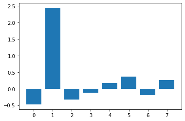

```python
from matplotlib import pyplot
# get importance
importance = logistic.coef_[0]
# summarize feature importance
for i,v in enumerate(importance):
    print('Feature: %0d, Score: %.5f' % (i,v))


# plot feature importance
pyplot.bar([x for x in range(len(importance))], importance)
pyplot.show()
```

```
[[137  20]
 [ 30  81]]
```

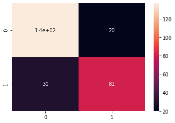

```python
cm1 = metrics.confusion_matrix(y_test, y_pred1)
print(cm1)
sns.heatmap(cm1, annot=True)
plt.show()
```

### 5.3 Random Forest

```python
# Create the parameter grid based on the results of random search
param_grid = {
    'bootstrap': [True],
    'max_depth': [3, 5, 10, 15, 20],
    'min_samples_leaf': [1, 3, 5],
    'min_samples_split': [5, 8, 10, 12],
    'n_estimators': [10, 30, 50, 80, 100]
}
# Create a based model
rf = RandomForestClassifier()
# Instantiate the grid search model
grid_search = GridSearchCV(estimator = rf, param_grid = param_grid,
                          cv = 5, n_jobs = -1, verbose = 2)

# Fit the grid search to the data
grid_search.fit(X_train, y_train)
grid_search.best_params_
```

```
Fitting 5 folds for each of 300 candidates, totalling 1500 fits
```

[output not shown]

```
{'bootstrap': True,
 'max_depth': 20,
 'min_samples_leaf': 3,
 'min_samples_split': 8,
 'n_estimators': 100}
```

```python
rand_forest = RandomForestClassifier(n_estimators=100, max_depth=20, min_samples_leaf=3, min_samples_split=8)
rand_forest.fit(X_train, y_train)

y_pred2 = rand_forest.predict(X_test)
#acc_rand_forest = round(rand_forest.score(X_test, y_test) * 100, 4)
#acc_rand_forest
```

```python
# Check the metrics to see the performance
# accuracy: (tp + tn) / (p + n)
accuracy = metrics.accuracy_score(y_test, y_pred2)
print('Accuracy: %f' % accuracy)
# precision tp / (tp + fp)
precision = metrics.precision_score(y_test, y_pred2)
print('Precision: %f' % precision)
# recall: tp / (tp + fn)
recall = metrics.recall_score(y_test, y_pred2)
print('Recall: %f' % recall)
# f1: 2 tp / (2 tp + fp + fn)
f1 = metrics.f1_score(y_test, y_pred2)
print('F1 score: %f' % f1)
forest = [accuracy, precision, recall, f1]
```

```
Accuracy: 0.805970
Precision: 0.824176
Recall: 0.675676
F1 score: 0.742574
```

```
Feature: 0, Score: 0.12146
Feature: 1, Score: 0.43157
Feature: 2, Score: 0.05315
Feature: 3, Score: 0.04845
Feature: 4, Score: 0.09644
Feature: 5, Score: 0.04537
Feature: 6, Score: 0.08594
Feature: 7, Score: 0.11763
```

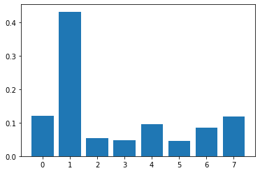

```python
# get importance
importance = rand_forest.feature_importances_
# summarize feature importance
for i,v in enumerate(importance):
    print('Feature: %0d, Score: %.5f' % (i,v))


# plot feature importance
pyplot.bar([x for x in range(len(importance))], importance)
pyplot.show()
```

```
[[141  16]
 [ 36  75]]
```

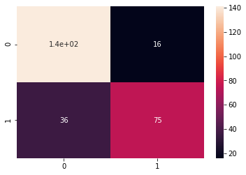

```python
cm2 = metrics.confusion_matrix(y_test, y_pred2)
print(cm2)
sns.heatmap(cm2, annot=True)
plt.show()
```

### 5.5 Decision tree

```python
decision_tree = DecisionTreeClassifier()
decision_tree.fit(X_train, y_train)
y_pred3 = decision_tree.predict(X_test)
#acc_decision_tree = round(decision_tree.score(X_test, y_test) * 100, 4)
#acc_decision_tree
```

[output not shown]

```python
# Check the metrics to see the performance
# accuracy: (tp + tn) / (p + n)
accuracy = metrics.accuracy_score(y_test, y_pred3)
print('Accuracy: %f' % accuracy)
# precision tp / (tp + fp)
precision = metrics.precision_score(y_test, y_pred3)
print('Precision: %f' % precision)
# recall: tp / (tp + fn)
recall = metrics.recall_score(y_test, y_pred3)
print('Recall: %f' % recall)
# f1: 2 tp / (2 tp + fp + fn)
f1 = metrics.f1_score(y_test, y_pred3)
print('F1 score: %f' % f1)
tree = [accuracy, precision, recall, f1]
```

```
Accuracy: 0.783582
Precision: 0.767677
Recall: 0.684685
F1 score: 0.723810
```

```
Feature: 0, Score: 0.15446
Feature: 1, Score: 0.36586
Feature: 2, Score: 0.09045
Feature: 3, Score: 0.05378
Feature: 4, Score: 0.09009
Feature: 5, Score: 0.06746
Feature: 6, Score: 0.09267
Feature: 7, Score: 0.08524
```

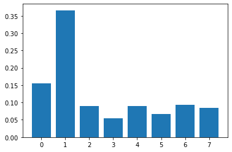

```python
# get importance
importance = decision_tree.feature_importances_
# summarize feature importance
for i,v in enumerate(importance):
    print('Feature: %0d, Score: %.5f' % (i,v))


# plot feature importance
pyplot.bar([x for x in range(len(importance))], importance)
pyplot.show()
```

```
[[132  25]
 [ 33  78]]
```

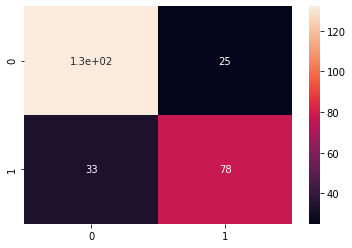

```python
cm3 = metrics.confusion_matrix(y_test, y_pred3)
print(cm3)
sns.heatmap(cm3, annot=True)
plt.show()
```

### 5.6 K Nearest Neighbors

```python
estimator_KNN = KNeighborsClassifier()
k_range = list(range(1, 50))
param = dict(n_neighbors=k_range)

# with GridSearch
grid_search_KNN = GridSearchCV(
    estimator=estimator_KNN,
    param_grid = param,
    scoring = 'accuracy',
    cv = 5
)
grid_search_KNN.fit(X_train, y_train)

#Parameter setting that gave the best results on the hold out data.
print(grid_search_KNN.best_params_ )
#Mean cross-validated score of the best_estimator
print('Best Score - KNN:', grid_search_KNN.best_score_ )
```

```
{'n_neighbors': 3}
Best Score - KNN: 0.7785677419354838
```

```python
# KNN
knn = KNeighborsClassifier(n_neighbors = 3)
knn.fit(X_train, y_train)
y_pred4 = knn.predict(X_test)
```

```python
# Check the metrics to see the performance
# accuracy: (tp + tn) / (p + n)
accuracy = metrics.accuracy_score(y_test, y_pred4)
print('Accuracy: %f' % accuracy)
# precision tp / (tp + fp)
precision = metrics.precision_score(y_test, y_pred4)
print('Precision: %f' % precision)
# recall: tp / (tp + fn)
recall = metrics.recall_score(y_test, y_pred4)
print('Recall: %f' % recall)
# f1: 2 tp / (2 tp + fp + fn)
f1 = metrics.f1_score(y_test, y_pred4)
print('F1 score: %f' % f1)
kneighbor = [accuracy, precision, recall, f1]
```

```
Accuracy: 0.768657
Precision: 0.742574
Recall: 0.675676
F1 score: 0.707547
```

```
[[131  26]
 [ 36  75]]
```

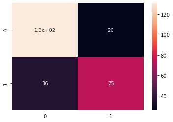

```python
cm4 = metrics.confusion_matrix(y_test, y_pred4)
print(cm4)
sns.heatmap(cm4, annot=True)
plt.show()
```

## 6. Model Comparison & Result

From the feature importance scores, we could know that sex is the most important feature among all 8 features.  
I calculated 4 metrics to compare the 4 models: accuracy, precision, recall and F1 score.

```python
result = pd.DataFrame(np.array([log, forest, tree, kneighbor]),
                   columns=['Accuracy', 'Precision', 'Recall', 'F1 Score'])
model = ['Logistic Regression', 'Random Forest', 'Decision Tree', 'K Nearest Neighbors']
result['Model'] = model
result = result[['Model','Accuracy', 'Precision', 'Recall', 'F1 Score']]
result
```

|  | Model | Accuracy | Precision | Recall | F1 Score |
| --- | --- | --- | --- | --- | --- |
| 0 | Logistic Regression | 0.813433 | 0.801980 | 0.729730 | 0.764151 |
| 1 | Random Forest | 0.805970 | 0.824176 | 0.675676 | 0.742574 |
| 2 | Decision Tree | 0.783582 | 0.767677 | 0.684685 | 0.723810 |
| 3 | K Nearest Neighbors | 0.768657 | 0.742574 | 0.675676 | 0.707547 |

From the above table, we know that the logistic regression has the highest accuracy among all 4 models while Random Forest has the highest precision. Under this specific case, precision means the percentage of people who are actually survived among all people who are predicted to be survived.  
But when looking at the overall performance, I would choose Logistic regression.

```
LR: 0.803583 (0.031122)
RF: 0.801373 (0.036082)
DT: 0.786767 (0.040760)
KNN: 0.784544 (0.057763)
```

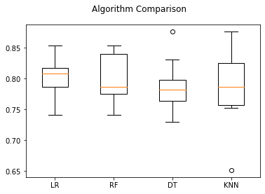

```python
# Perform k-fold cross validation
seed = 10
# prepare models
models = []
models.append(('LR', LogisticRegression()))
models.append(('RF', RandomForestClassifier()))
models.append(('DT', DecisionTreeClassifier()))
models.append(('KNN', KNeighborsClassifier()))


# evaluate each model in turn
results = []
names = []
scoring = 'accuracy'
for name, model in models:
    kfold = model_selection.KFold(n_splits=10, random_state=seed)
    cv_results = model_selection.cross_val_score(model, X, y, cv=kfold, scoring=scoring)
    results.append(cv_results)
    names.append(name)
    msg = "%s: %f (%f)" % (name, cv_results.mean(), cv_results.std())
    print(msg)


# boxplot algorithm comparison
fig = plt.figure()
fig.suptitle('Algorithm Comparison')
ax = fig.add_subplot(111)
plt.boxplot(results)
ax.set_xticklabels(names)
plt.show()
```

From the above plot, we could see that the average accuracy is still highest for logistic regression. Random forest has similar performance to logistic regression with wider interquartile range. KNN has a wider interquartile range and a higher upper bound but has an apparent lower outlier. Decision tree has similar average accuracy to KNN but has narrower range and also has an outlier.  
Overall, I would still choose logistic regression here.

## 7. Deploy Model to Production

We could use the model to create a web service for prediction using Flask web framework. After training and choosing proper models, we need to persist the model. For example, we could store the trained model in a pickle file using scikit-learn. The process of seperating training environment and actual application environment helps to optimize the effort since they require different resources. Lastly, we could use Flask web framework to serve the model. This often hosts in cloud server.